# Supervised Learning : Exploring Penalized Models for Predicting Numeric Responses

### John Pauline Pineda *November 17, 2023*

- **1. Table of Contents**
  - 1.1 Data Background
  - 1.2 Data Description
  - 1.3 Data Quality Assessment
  - 1.4 Data Preprocessing
    - 1.4.1 Data Cleaning
    - 1.4.2 Missing Data Imputation
    - 1.4.3 Outlier Treatment
    - 1.4.4 Collinearity
    - 1.4.5 Shape Transformation
    - 1.4.6 Centering and Scaling
    - 1.4.7 Data Encoding
    - 1.4.8 Preprocessed Data Description
  - 1.5 Data Exploration
    - 1.5.1 Exploratory Data Analysis
    - 1.5.2 Hypothesis Testing
  - 1.6 Model Development
    - 1.6.1 Premodelling Data Description
    - 1.6.2 Linear Regression
    - 1.6.3 Polynomial Regression
    - 1.6.4 Ridge Regression
    - 1.6.5 Least Absolute Shrinkage and Selection Operator Regression
    - 1.6.6 Elastic Net Regression
  - 1.7 Consolidated Findings
- **2. Summary**
- **3. References**

# 1. Table of Contents

This project implements different penalized regression modelling procedures for numeric responses using various helpful packages in **Python**. Models applied in the analysis to predict numeric responses included the **Linear Regression**, **Polynomial Regression**, **Ridge Regression**, **Least Absolute Shrinkage and Selection Operator Regression** and **Elastic Net Regression** algorithms. The resulting predictions derived from the candidate models were evaluated in terms of their model fit using the r-squared, mean squared error (MSE) and mean absolute error (MAE) metrics. All results were consolidated in a **Summary** presented at the end of the document.

[Penalized regression](https://link.springer.com/book/10.1007/978-1-4614-6849-3?page=1) is a form of variable selection method aimed at reducing model complexity by seeking a smaller subset of informative variables. This process keeps all the predictor variables in the model but constrains (regularizes) the regression coefficients by shrinking them toward zero, in addition to setting some coefficients exactly equal to zero, and is directly built as extensions of standard regression coefficient estimation by incorporating a penalty in the loss function. The algorithms applied in this study attempt to evaluate various penalties for over-confidence in the parameter estimates and accept a slightly worse fit in order to have a more parsimonious model.

## 1.1. Data Background

Datasets used for the analysis were separately gathered and consolidated from various sources including:

1. Cancer Rates from [World Population Review](https://worldpopulationreview.com/country-rankings/cancer-rates-by-country)
2. Social Protection and Labor Indicator from [World Bank](https://data.worldbank.org/topic/social-protection-and-labor?view=chart)
3. Education Indicator from [World Bank](https://data.worldbank.org/topic/education?view=chart)
4. Economy and Growth Indicator from [World Bank](https://data.worldbank.org/topic/economy-and-growth?view=chart)
5. Environment Indicator from [World Bank](https://data.worldbank.org/topic/environment?view=chart)
6. Climate Change Indicator from [World Bank](https://data.worldbank.org/topic/climate-change?view=chart)
7. Agricultural and Rural Development Indicator from [World Bank](https://data.worldbank.org/topic/agriculture-and-rural-development?view=chart)
8. Social Development Indicator from [World Bank](https://data.worldbank.org/topic/social-development?view=chart)
9. Health Indicator from [World Bank](https://data.worldbank.org/topic/health?view=chart)
10. Science and Technology Indicator from [World Bank](https://data.worldbank.org/topic/science-and-technology?view=chart)
11. Urban Development Indicator from [World Bank](https://data.worldbank.org/topic/urban-development?view=chart)
12. Human Development Indices from [Human Development Reports](https://hdr.undp.org/data-center/human-development-index#/indicies/HDI)
13. Environmental Performance Indices from [Yale Center for Environmental Law and Policy](https://epi.yale.edu/epi-results/2022/component/epi)

This study hypothesized that various global development indicators and indices influence cancer rates across countries.

The target variable for the study is:

- CANRAT - Age-standardized cancer rates, per 100K population (2022)

The predictor variables for the study are:

- GDPPER - GDP per person employed, current US Dollars (2020)
- URBPOP - Urban population, % of total population (2020)
- PATRES - Patent applications by residents, total count (2020)
- RNDGDP - Research and development expenditure, % of GDP (2020)
- POPGRO - Population growth, annual % (2020)
- LIFEXP - Life expectancy at birth, total in years (2020)
- TUBINC - Incidence of tuberculosis, per 100K population (2020)
- DTHCMD - Cause of death by communicable diseases and maternal, prenatal and nutrition conditions, % of total (2019)
- AGRLND - Agricultural land, % of land area (2020)
- GHGEMI - Total greenhouse gas emissions, kt of CO2 equivalent (2020)
- RELOUT - Renewable electricity output, % of total electricity output (2015)
- METEMI - Methane emissions, kt of CO2 equivalent (2020)
- FORARE - Forest area, % of land area (2020)
- CO2EMI - CO2 emissions, metric tons per capita (2020)
- PM2EXP - PM2.5 air pollution, population exposed to levels exceeding WHO guideline value, % of total (2017)
- POPDEN - Population density, people per sq. km of land area (2020)
- GDPCAP - GDP per capita, current US Dollars (2020)
- ENRTER - Tertiary school enrollment, % gross (2020)
- HDICAT - Human development index, ordered category (2020)
- EPISCO - Environment performance index , score (2022)

## 1.2. Data Description

1. The dataset is comprised of:
   - **177 rows** (observations)
   - **22 columns** (variables)
     - **1/22 metadata** (object)
       - COUNTRY
     - **1/22 target** (numeric)
       - CANRAT
     - **19/22 predictor** (numeric)
       - GDPPER
       - URBPOP
       - PATRES
       - RNDGDP
       - POPGRO
       - LIFEXP
       - TUBINC
       - DTHCMD
       - AGRLND
       - GHGEMI
       - RELOUT
       - METEMI
       - FORARE
       - CO2EMI
       - PM2EXP
       - POPDEN
       - GDPCAP
       - ENRTER
       - EPISCO
     - **1/22 predictor** (categorical)
       - HDICAT

```python
##################################
# Loading Python Libraries
##################################
import numpy as np
import pandas as pd
import seaborn as sns
import matplotlib.pyplot as plt
import itertools
%matplotlib inline

from operator import add,mul,truediv
from sklearn.experimental import enable_iterative_imputer
from sklearn.impute import IterativeImputer
from sklearn.linear_model import LinearRegression
from sklearn.preprocessing import PowerTransformer
from sklearn.preprocessing import StandardScaler
from scipy import stats

from sklearn.linear_model import Ridge,Lasso,ElasticNet
from sklearn.linear_model import RidgeCV, LassoCV, ElasticNetCV
from sklearn.metrics import r2_score,mean_squared_error,mean_absolute_error
from sklearn.model_selection import train_test_split, KFold, GridSearchCV, RepeatedKFold, LeaveOneOut
from sklearn.preprocessing import PolynomialFeatures
from sklearn.pipeline import Pipeline
```

```python
##################################
# Setting Global Options
##################################
np.set_printoptions(suppress=True, precision=4)
pd.options.display.float_format = '{:.4f}'.format
```

```python
##################################
# Loading the dataset
##################################
cancer_rate = pd.read_csv('NumericCancerRates.csv')
```

```python
##################################
# Performing a general exploration of the dataset
##################################
print('Dataset Dimensions: ')
display(cancer_rate.shape)
```

```
Dataset Dimensions:
```

```
(177, 22)
```

```python
##################################
# Listing the column names and data types
##################################
print('Column Names and Data Types:')
display(cancer_rate.dtypes)
```

```
Column Names and Data Types:
```

```
COUNTRY     object
CANRAT     float64
GDPPER     float64
URBPOP     float64
PATRES     float64
RNDGDP     float64
POPGRO     float64
LIFEXP     float64
TUBINC     float64
DTHCMD     float64
AGRLND     float64
GHGEMI     float64
RELOUT     float64
METEMI     float64
FORARE     float64
CO2EMI     float64
PM2EXP     float64
POPDEN     float64
ENRTER     float64
GDPCAP     float64
HDICAT      object
EPISCO     float64
dtype: object
```

```python
##################################
# Taking a snapshot of the dataset
##################################
cancer_rate.head()
```

|  | COUNTRY | CANRAT | GDPPER | URBPOP | PATRES | RNDGDP | POPGRO | LIFEXP | TUBINC | DTHCMD | ... | RELOUT | METEMI | FORARE | CO2EMI | PM2EXP | POPDEN | ENRTER | GDPCAP | HDICAT | EPISCO |
| --- | --- | --- | --- | --- | --- | --- | --- | --- | --- | --- | --- | --- | --- | --- | --- | --- | --- | --- | --- | --- | --- |
| 0 | Australia | 452.4000 | 98380.6360 | 86.2410 | 2368.0000 | NaN | 1.2357 | 83.2000 | 7.2000 | 4.9411 | ... | 13.6378 | 131484.7632 | 17.4213 | 14.7727 | 24.8936 | 3.3353 | 110.1392 | 51722.0690 | VH | 60.1000 |
| 1 | New Zealand | 422.9000 | 77541.7644 | 86.6990 | 348.0000 | NaN | 2.2048 | 82.2561 | 7.2000 | 4.3547 | ... | 80.0814 | 32241.9370 | 37.5701 | 6.1608 | NaN | 19.3316 | 75.7348 | 41760.5948 | VH | 56.7000 |
| 2 | Ireland | 372.8000 | 198405.8750 | 63.6530 | 75.0000 | 1.2324 | 1.0291 | 82.5561 | 5.3000 | 5.6846 | ... | 27.9654 | 15252.8246 | 11.3517 | 6.7682 | 0.2741 | 72.3673 | 74.6803 | 85420.1909 | VH | 57.4000 |
| 3 | United States | 362.2000 | 130941.6369 | 82.6640 | 269586.0000 | 3.4229 | 0.9643 | 76.9805 | 2.3000 | 5.3021 | ... | 13.2286 | 748241.4029 | 33.8669 | 13.0328 | 3.3432 | 36.2410 | 87.5677 | 63528.6343 | VH | 51.1000 |
| 4 | Denmark | 351.1000 | 113300.6011 | 88.1160 | 1261.0000 | 2.9687 | 0.2916 | 81.6024 | 4.1000 | 6.8261 | ... | 65.5059 | 7778.7739 | 15.7110 | 4.6912 | 56.9145 | 145.7851 | 82.6643 | 60915.4244 | VH | 77.9000 |

5 rows × 22 columns

```python
##################################
# Setting the levels of the categorical variables
##################################
cancer_rate['HDICAT'] = cancer_rate['HDICAT'].astype('category')
cancer_rate['HDICAT'] = cancer_rate['HDICAT'].cat.set_categories(['L', 'M', 'H', 'VH'], ordered=True)
```

```python
##################################
# Performing a general exploration of the numeric variables
##################################
print('Numeric Variable Summary:')
display(cancer_rate.describe(include='number').transpose())
```

```
Numeric Variable Summary:
```

|  | count | mean | std | min | 25% | 50% | 75% | max |
| --- | --- | --- | --- | --- | --- | --- | --- | --- |
| CANRAT | 177.0000 | 183.8294 | 79.7434 | 78.4000 | 118.1000 | 155.3000 | 240.4000 | 452.4000 |
| GDPPER | 165.0000 | 45284.4243 | 39417.9404 | 1718.8049 | 13545.2545 | 34024.9009 | 66778.4160 | 234646.9049 |
| URBPOP | 174.0000 | 59.7881 | 22.8064 | 13.3450 | 42.4327 | 61.7015 | 79.1865 | 100.0000 |
| PATRES | 108.0000 | 20607.3889 | 134068.3101 | 1.0000 | 35.2500 | 244.5000 | 1297.7500 | 1344817.0000 |
| RNDGDP | 74.0000 | 1.1975 | 1.1900 | 0.0398 | 0.2564 | 0.8737 | 1.6088 | 5.3545 |
| POPGRO | 174.0000 | 1.1270 | 1.1977 | -2.0793 | 0.2369 | 1.1800 | 2.0312 | 3.7271 |
| LIFEXP | 174.0000 | 71.7461 | 7.6062 | 52.7770 | 65.9075 | 72.4646 | 77.5235 | 84.5600 |
| TUBINC | 174.0000 | 105.0059 | 136.7229 | 0.7700 | 12.0000 | 44.5000 | 147.7500 | 592.0000 |
| DTHCMD | 170.0000 | 21.2605 | 19.2733 | 1.2836 | 6.0780 | 12.4563 | 36.9805 | 65.2079 |
| AGRLND | 174.0000 | 38.7935 | 21.7155 | 0.5128 | 20.1303 | 40.3866 | 54.0138 | 80.8411 |
| GHGEMI | 170.0000 | 259582.7099 | 1118549.7301 | 179.7252 | 12527.4874 | 41009.2760 | 116482.5786 | 12942868.3400 |
| RELOUT | 153.0000 | 39.7600 | 31.9149 | 0.0003 | 10.5827 | 32.3817 | 63.0115 | 100.0000 |
| METEMI | 170.0000 | 47876.1336 | 134661.0653 | 11.5961 | 3662.8849 | 11118.9760 | 32368.9090 | 1186285.1810 |
| FORARE | 173.0000 | 32.2182 | 23.1200 | 0.0081 | 11.6044 | 31.5090 | 49.0718 | 97.4121 |
| CO2EMI | 170.0000 | 3.7511 | 4.6065 | 0.0326 | 0.6319 | 2.2984 | 4.8235 | 31.7268 |
| PM2EXP | 167.0000 | 91.9406 | 22.0600 | 0.2741 | 99.6271 | 100.0000 | 100.0000 | 100.0000 |
| POPDEN | 174.0000 | 200.8868 | 645.3834 | 2.1151 | 27.4545 | 77.9831 | 153.9936 | 7918.9513 |
| ENRTER | 116.0000 | 49.9950 | 29.7062 | 2.4326 | 22.1072 | 53.3925 | 71.0575 | 143.3107 |
| GDPCAP | 170.0000 | 13992.0956 | 19579.5430 | 216.8274 | 1870.5030 | 5348.1929 | 17421.1162 | 117370.4969 |
| EPISCO | 165.0000 | 42.9467 | 12.4909 | 18.9000 | 33.0000 | 40.9000 | 50.5000 | 77.9000 |

```python
##################################
# Performing a general exploration of the object variable
##################################
print('Object Variable Summary:')
display(cancer_rate.describe(include='object').transpose())
```

```
Object Variable Summary:
```

|  | count | unique | top | freq |
| --- | --- | --- | --- | --- |
| COUNTRY | 177 | 177 | Australia | 1 |

```python
##################################
# Performing a general exploration of the categorical variable
##################################
print('Categorical Variable Summary:')
display(cancer_rate.describe(include='category').transpose())
```

```
Categorical Variable Summary:
```

|  | count | unique | top | freq |
| --- | --- | --- | --- | --- |
| HDICAT | 167 | 4 | VH | 59 |

## 1.3. Data Quality Assessment

Data quality findings based on assessment are as follows:

```python
##################################
# Counting the number of duplicated rows
##################################
cancer_rate.duplicated().sum()
```

```
0
```

```python
##################################
# Gathering the data types for each column
##################################
data_type_list = list(cancer_rate.dtypes)
```

```python
##################################
# Gathering the variable names for each column
##################################
variable_name_list = list(cancer_rate.columns)
```

```python
##################################
# Gathering the number of observations for each column
##################################
row_count_list = list([len(cancer_rate)] * len(cancer_rate.columns))
```

```python
##################################
# Gathering the number of missing data for each column
##################################
null_count_list = list(cancer_rate.isna().sum(axis=0))
```

```python
##################################
# Gathering the number of non-missing data for each column
##################################
non_null_count_list = list(cancer_rate.count())
```

```python
##################################
# Gathering the missing data percentage for each column
##################################
fill_rate_list = map(truediv, non_null_count_list, row_count_list)
```

```python
##################################
# Formulating the summary
# for all columns
##################################
all_column_quality_summary = pd.DataFrame(zip(variable_name_list,
                                              data_type_list,
                                              row_count_list,
                                              non_null_count_list,
                                              null_count_list,
                                              fill_rate_list),
                                        columns=['Column.Name',
                                                 'Column.Type',
                                                 'Row.Count',
                                                 'Non.Null.Count',
                                                 'Null.Count',
                                                 'Fill.Rate'])
display(all_column_quality_summary)
```

|  | Column.Name | Column.Type | Row.Count | Non.Null.Count | Null.Count | Fill.Rate |
| --- | --- | --- | --- | --- | --- | --- |
| 0 | COUNTRY | object | 177 | 177 | 0 | 1.0000 |
| 1 | CANRAT | float64 | 177 | 177 | 0 | 1.0000 |
| 2 | GDPPER | float64 | 177 | 165 | 12 | 0.9322 |
| 3 | URBPOP | float64 | 177 | 174 | 3 | 0.9831 |
| 4 | PATRES | float64 | 177 | 108 | 69 | 0.6102 |
| 5 | RNDGDP | float64 | 177 | 74 | 103 | 0.4181 |
| 6 | POPGRO | float64 | 177 | 174 | 3 | 0.9831 |
| 7 | LIFEXP | float64 | 177 | 174 | 3 | 0.9831 |
| 8 | TUBINC | float64 | 177 | 174 | 3 | 0.9831 |
| 9 | DTHCMD | float64 | 177 | 170 | 7 | 0.9605 |
| 10 | AGRLND | float64 | 177 | 174 | 3 | 0.9831 |
| 11 | GHGEMI | float64 | 177 | 170 | 7 | 0.9605 |
| 12 | RELOUT | float64 | 177 | 153 | 24 | 0.8644 |
| 13 | METEMI | float64 | 177 | 170 | 7 | 0.9605 |
| 14 | FORARE | float64 | 177 | 173 | 4 | 0.9774 |
| 15 | CO2EMI | float64 | 177 | 170 | 7 | 0.9605 |
| 16 | PM2EXP | float64 | 177 | 167 | 10 | 0.9435 |
| 17 | POPDEN | float64 | 177 | 174 | 3 | 0.9831 |
| 18 | ENRTER | float64 | 177 | 116 | 61 | 0.6554 |
| 19 | GDPCAP | float64 | 177 | 170 | 7 | 0.9605 |
| 20 | HDICAT | category | 177 | 167 | 10 | 0.9435 |
| 21 | EPISCO | float64 | 177 | 165 | 12 | 0.9322 |

```python
##################################
# Counting the number of columns
# with Fill.Rate < 1.00
##################################
len(all_column_quality_summary[(all_column_quality_summary['Fill.Rate']<1)])
```

```
20
```

```python
##################################
# Identifying the columns
# with Fill.Rate < 1.00
##################################
display(all_column_quality_summary[(all_column_quality_summary['Fill.Rate']<1)].sort_values(by=['Fill.Rate'], ascending=True))
```

|  | Column.Name | Column.Type | Row.Count | Non.Null.Count | Null.Count | Fill.Rate |
| --- | --- | --- | --- | --- | --- | --- |
| 5 | RNDGDP | float64 | 177 | 74 | 103 | 0.4181 |
| 4 | PATRES | float64 | 177 | 108 | 69 | 0.6102 |
| 18 | ENRTER | float64 | 177 | 116 | 61 | 0.6554 |
| 12 | RELOUT | float64 | 177 | 153 | 24 | 0.8644 |
| 2 | GDPPER | float64 | 177 | 165 | 12 | 0.9322 |
| 21 | EPISCO | float64 | 177 | 165 | 12 | 0.9322 |
| 20 | HDICAT | category | 177 | 167 | 10 | 0.9435 |
| 16 | PM2EXP | float64 | 177 | 167 | 10 | 0.9435 |
| 9 | DTHCMD | float64 | 177 | 170 | 7 | 0.9605 |
| 13 | METEMI | float64 | 177 | 170 | 7 | 0.9605 |
| 15 | CO2EMI | float64 | 177 | 170 | 7 | 0.9605 |
| 19 | GDPCAP | float64 | 177 | 170 | 7 | 0.9605 |
| 11 | GHGEMI | float64 | 177 | 170 | 7 | 0.9605 |
| 14 | FORARE | float64 | 177 | 173 | 4 | 0.9774 |
| 8 | TUBINC | float64 | 177 | 174 | 3 | 0.9831 |
| 10 | AGRLND | float64 | 177 | 174 | 3 | 0.9831 |
| 6 | POPGRO | float64 | 177 | 174 | 3 | 0.9831 |
| 17 | POPDEN | float64 | 177 | 174 | 3 | 0.9831 |
| 3 | URBPOP | float64 | 177 | 174 | 3 | 0.9831 |
| 7 | LIFEXP | float64 | 177 | 174 | 3 | 0.9831 |

```python
##################################
# Identifying the rows
# with Fill.Rate < 0.90
##################################
column_low_fill_rate = all_column_quality_summary[(all_column_quality_summary['Fill.Rate']<0.90)]
```

```python
##################################
# Gathering the metadata labels for each observation
##################################
row_metadata_list = cancer_rate["COUNTRY"].values.tolist()
```

```python
##################################
# Gathering the number of columns for each observation
##################################
column_count_list = list([len(cancer_rate.columns)] * len(cancer_rate))
```

```python
##################################
# Gathering the number of missing data for each row
##################################
null_row_list = list(cancer_rate.isna().sum(axis=1))
```

```python
##################################
# Gathering the missing data percentage for each column
##################################
missing_rate_list = map(truediv, null_row_list, column_count_list)
```

```python
##################################
# Identifying the rows
# with missing data
##################################
all_row_quality_summary = pd.DataFrame(zip(row_metadata_list,
                                           column_count_list,
                                           null_row_list,
                                           missing_rate_list),
                                        columns=['Row.Name',
                                                 'Column.Count',
                                                 'Null.Count',
                                                 'Missing.Rate'])
display(all_row_quality_summary)
```

|  | Row.Name | Column.Count | Null.Count | Missing.Rate |
| --- | --- | --- | --- | --- |
| 0 | Australia | 22 | 1 | 0.0455 |
| 1 | New Zealand | 22 | 2 | 0.0909 |
| 2 | Ireland | 22 | 0 | 0.0000 |
| 3 | United States | 22 | 0 | 0.0000 |
| 4 | Denmark | 22 | 0 | 0.0000 |
| ... | ... | ... | ... | ... |
| 172 | Congo Republic | 22 | 3 | 0.1364 |
| 173 | Bhutan | 22 | 2 | 0.0909 |
| 174 | Nepal | 22 | 2 | 0.0909 |
| 175 | Gambia | 22 | 4 | 0.1818 |
| 176 | Niger | 22 | 2 | 0.0909 |

177 rows × 4 columns

```python
##################################
# Counting the number of rows
# with Missing.Rate > 0.00
##################################
len(all_row_quality_summary[(all_row_quality_summary['Missing.Rate']>0.00)])
```

```
120
```

```python
##################################
# Counting the number of rows
# with Missing.Rate > 0.20
##################################
len(all_row_quality_summary[(all_row_quality_summary['Missing.Rate']>0.20)])
```

```
14
```

```python
##################################
# Identifying the rows
# with Missing.Rate > 0.20
##################################
row_high_missing_rate = all_row_quality_summary[(all_row_quality_summary['Missing.Rate']>0.20)]
```

```python
##################################
# Identifying the rows
# with Missing.Rate > 0.20
##################################
display(all_row_quality_summary[(all_row_quality_summary['Missing.Rate']>0.20)].sort_values(by=['Missing.Rate'], ascending=False))
```

|  | Row.Name | Column.Count | Null.Count | Missing.Rate |
| --- | --- | --- | --- | --- |
| 35 | Guadeloupe | 22 | 20 | 0.9091 |
| 39 | Martinique | 22 | 20 | 0.9091 |
| 56 | French Guiana | 22 | 20 | 0.9091 |
| 13 | New Caledonia | 22 | 11 | 0.5000 |
| 44 | French Polynesia | 22 | 11 | 0.5000 |
| 75 | Guam | 22 | 11 | 0.5000 |
| 53 | Puerto Rico | 22 | 9 | 0.4091 |
| 85 | North Korea | 22 | 6 | 0.2727 |
| 132 | Somalia | 22 | 6 | 0.2727 |
| 168 | South Sudan | 22 | 6 | 0.2727 |
| 73 | Venezuela | 22 | 5 | 0.2273 |
| 117 | Libya | 22 | 5 | 0.2273 |
| 161 | Eritrea | 22 | 5 | 0.2273 |
| 164 | Yemen | 22 | 5 | 0.2273 |

```python
##################################
# Formulating the dataset
# with numeric columns only
##################################
cancer_rate_numeric = cancer_rate.select_dtypes(include='number')
```

```python
##################################
# Gathering the variable names for each numeric column
##################################
numeric_variable_name_list = cancer_rate_numeric.columns
```

```python
##################################
# Gathering the minimum value for each numeric column
##################################
numeric_minimum_list = cancer_rate_numeric.min()
```

```python
##################################
# Gathering the mean value for each numeric column
##################################
numeric_mean_list = cancer_rate_numeric.mean()
```

```python
##################################
# Gathering the median value for each numeric column
##################################
numeric_median_list = cancer_rate_numeric.median()
```

```python
##################################
# Gathering the maximum value for each numeric column
##################################
numeric_maximum_list = cancer_rate_numeric.max()
```

```python
##################################
# Gathering the first mode values for each numeric column
##################################
numeric_first_mode_list = [cancer_rate[x].value_counts(dropna=True).index.tolist()[0] for x in cancer_rate_numeric]
```

```python
##################################
# Gathering the second mode values for each numeric column
##################################
numeric_second_mode_list = [cancer_rate[x].value_counts(dropna=True).index.tolist()[1] for x in cancer_rate_numeric]
```

```python
##################################
# Gathering the count of first mode values for each numeric column
##################################
numeric_first_mode_count_list = [cancer_rate_numeric[x].isin([cancer_rate[x].value_counts(dropna=True).index.tolist()[0]]).sum() for x in cancer_rate_numeric]
```

```python
##################################
# Gathering the count of second mode values for each numeric column
##################################
numeric_second_mode_count_list = [cancer_rate_numeric[x].isin([cancer_rate[x].value_counts(dropna=True).index.tolist()[1]]).sum() for x in cancer_rate_numeric]
```

```python
##################################
# Gathering the first mode to second mode ratio for each numeric column
##################################
numeric_first_second_mode_ratio_list = map(truediv, numeric_first_mode_count_list, numeric_second_mode_count_list)
```

```python
##################################
# Gathering the count of unique values for each numeric column
##################################
numeric_unique_count_list = cancer_rate_numeric.nunique(dropna=True)
```

```python
##################################
# Gathering the number of observations for each numeric column
##################################
numeric_row_count_list = list([len(cancer_rate_numeric)] * len(cancer_rate_numeric.columns))
```

```python
##################################
# Gathering the unique to count ratio for each numeric column
##################################
numeric_unique_count_ratio_list = map(truediv, numeric_unique_count_list, numeric_row_count_list)
```

```python
##################################
# Gathering the skewness value for each numeric column
##################################
numeric_skewness_list = cancer_rate_numeric.skew()
```

```python
##################################
# Gathering the kurtosis value for each numeric column
##################################
numeric_kurtosis_list = cancer_rate_numeric.kurtosis()
```

```python
numeric_column_quality_summary = pd.DataFrame(zip(numeric_variable_name_list,
                                                numeric_minimum_list,
                                                numeric_mean_list,
                                                numeric_median_list,
                                                numeric_maximum_list,
                                                numeric_first_mode_list,
                                                numeric_second_mode_list,
                                                numeric_first_mode_count_list,
                                                numeric_second_mode_count_list,
                                                numeric_first_second_mode_ratio_list,
                                                numeric_unique_count_list,
                                                numeric_row_count_list,
                                                numeric_unique_count_ratio_list,
                                                numeric_skewness_list,
                                                numeric_kurtosis_list),
                                        columns=['Numeric.Column.Name',
                                                 'Minimum',
                                                 'Mean',
                                                 'Median',
                                                 'Maximum',
                                                 'First.Mode',
                                                 'Second.Mode',
                                                 'First.Mode.Count',
                                                 'Second.Mode.Count',
                                                 'First.Second.Mode.Ratio',
                                                 'Unique.Count',
                                                 'Row.Count',
                                                 'Unique.Count.Ratio',
                                                 'Skewness',
                                                 'Kurtosis'])
display(numeric_column_quality_summary)
```

|  | Numeric.Column.Name | Minimum | Mean | Median | Maximum | First.Mode | Second.Mode | First.Mode.Count | Second.Mode.Count | First.Second.Mode.Ratio | Unique.Count | Row.Count | Unique.Count.Ratio | Skewness | Kurtosis |
| --- | --- | --- | --- | --- | --- | --- | --- | --- | --- | --- | --- | --- | --- | --- | --- |
| 0 | CANRAT | 78.4000 | 183.8294 | 155.3000 | 452.4000 | 135.3000 | 106.7000 | 3 | 2 | 1.5000 | 167 | 177 | 0.9435 | 0.8818 | 0.0635 |
| 1 | GDPPER | 1718.8049 | 45284.4243 | 34024.9009 | 234646.9049 | 98380.6360 | 42154.1781 | 1 | 1 | 1.0000 | 165 | 177 | 0.9322 | 1.5176 | 3.4720 |
| 2 | URBPOP | 13.3450 | 59.7881 | 61.7015 | 100.0000 | 100.0000 | 52.5160 | 2 | 1 | 2.0000 | 173 | 177 | 0.9774 | -0.2107 | -0.9628 |
| 3 | PATRES | 1.0000 | 20607.3889 | 244.5000 | 1344817.0000 | 6.0000 | 2.0000 | 4 | 3 | 1.3333 | 97 | 177 | 0.5480 | 9.2844 | 91.1872 |
| 4 | RNDGDP | 0.0398 | 1.1975 | 0.8737 | 5.3545 | 1.2324 | 0.9622 | 1 | 1 | 1.0000 | 74 | 177 | 0.4181 | 1.3967 | 1.6960 |
| 5 | POPGRO | -2.0793 | 1.1270 | 1.1800 | 3.7271 | 1.2357 | 1.4831 | 1 | 1 | 1.0000 | 174 | 177 | 0.9831 | -0.1952 | -0.4236 |
| 6 | LIFEXP | 52.7770 | 71.7461 | 72.4646 | 84.5600 | 83.2000 | 68.6870 | 1 | 1 | 1.0000 | 174 | 177 | 0.9831 | -0.3580 | -0.6496 |
| 7 | TUBINC | 0.7700 | 105.0059 | 44.5000 | 592.0000 | 12.0000 | 7.2000 | 4 | 3 | 1.3333 | 131 | 177 | 0.7401 | 1.7463 | 2.4294 |
| 8 | DTHCMD | 1.2836 | 21.2605 | 12.4563 | 65.2079 | 4.9411 | 42.0794 | 1 | 1 | 1.0000 | 170 | 177 | 0.9605 | 0.9005 | -0.6915 |
| 9 | AGRLND | 0.5128 | 38.7935 | 40.3866 | 80.8411 | 46.2525 | 72.0065 | 1 | 1 | 1.0000 | 174 | 177 | 0.9831 | 0.0740 | -0.9262 |
| 10 | GHGEMI | 179.7252 | 259582.7099 | 41009.2760 | 12942868.3400 | 571903.1199 | 3000.9323 | 1 | 1 | 1.0000 | 170 | 177 | 0.9605 | 9.4961 | 101.6373 |
| 11 | RELOUT | 0.0003 | 39.7600 | 32.3817 | 100.0000 | 100.0000 | 13.6378 | 3 | 1 | 3.0000 | 151 | 177 | 0.8531 | 0.5011 | -0.9818 |
| 12 | METEMI | 11.5961 | 47876.1336 | 11118.9760 | 1186285.1810 | 131484.7632 | 1326.0340 | 1 | 1 | 1.0000 | 170 | 177 | 0.9605 | 5.8010 | 38.6614 |
| 13 | FORARE | 0.0081 | 32.2182 | 31.5090 | 97.4121 | 17.4213 | 8.7822 | 1 | 1 | 1.0000 | 173 | 177 | 0.9774 | 0.5193 | -0.3226 |
| 14 | CO2EMI | 0.0326 | 3.7511 | 2.2984 | 31.7268 | 14.7727 | 0.9721 | 1 | 1 | 1.0000 | 170 | 177 | 0.9605 | 2.7216 | 10.3116 |
| 15 | PM2EXP | 0.2741 | 91.9406 | 100.0000 | 100.0000 | 100.0000 | 100.0000 | 106 | 2 | 53.0000 | 61 | 177 | 0.3446 | -3.1416 | 9.0324 |
| 16 | POPDEN | 2.1151 | 200.8868 | 77.9831 | 7918.9513 | 3.3353 | 13.3008 | 1 | 1 | 1.0000 | 174 | 177 | 0.9831 | 10.2678 | 119.9953 |
| 17 | ENRTER | 2.4326 | 49.9950 | 53.3925 | 143.3107 | 110.1392 | 45.2207 | 1 | 1 | 1.0000 | 116 | 177 | 0.6554 | 0.2759 | -0.3929 |
| 18 | GDPCAP | 216.8274 | 13992.0956 | 5348.1929 | 117370.4969 | 51722.0690 | 3961.7266 | 1 | 1 | 1.0000 | 170 | 177 | 0.9605 | 2.2586 | 5.9387 |
| 19 | EPISCO | 18.9000 | 42.9467 | 40.9000 | 77.9000 | 29.6000 | 43.6000 | 3 | 3 | 1.0000 | 137 | 177 | 0.7740 | 0.6418 | 0.0352 |

```python
##################################
# Counting the number of numeric columns
# with First.Second.Mode.Ratio > 5.00
##################################
len(numeric_column_quality_summary[(numeric_column_quality_summary['First.Second.Mode.Ratio']>5)])
```

```
1
```

```python
##################################
# Identifying the numeric columns
# with First.Second.Mode.Ratio > 5.00
##################################
display(numeric_column_quality_summary[(numeric_column_quality_summary['First.Second.Mode.Ratio']>5)].sort_values(by=['First.Second.Mode.Ratio'], ascending=False))
```

|  | Numeric.Column.Name | Minimum | Mean | Median | Maximum | First.Mode | Second.Mode | First.Mode.Count | Second.Mode.Count | First.Second.Mode.Ratio | Unique.Count | Row.Count | Unique.Count.Ratio | Skewness | Kurtosis |
| --- | --- | --- | --- | --- | --- | --- | --- | --- | --- | --- | --- | --- | --- | --- | --- |
| 15 | PM2EXP | 0.2741 | 91.9406 | 100.0000 | 100.0000 | 100.0000 | 100.0000 | 106 | 2 | 53.0000 | 61 | 177 | 0.3446 | -3.1416 | 9.0324 |

```python
##################################
# Counting the number of numeric columns
# with Unique.Count.Ratio > 10.00
##################################
len(numeric_column_quality_summary[(numeric_column_quality_summary['Unique.Count.Ratio']>10)])
```

```
0
```

```python
##################################
# Counting the number of numeric columns
# with Skewness > 3.00 or Skewness < -3.00
##################################
len(numeric_column_quality_summary[(numeric_column_quality_summary['Skewness']>3) | (numeric_column_quality_summary['Skewness']<(-3))])
```

```
5
```

```python
##################################
# Identifying the numeric columns
# with Skewness > 3.00 or Skewness < -3.00
##################################
display(numeric_column_quality_summary[(numeric_column_quality_summary['Skewness']>3) | (numeric_column_quality_summary['Skewness']<(-3))].sort_values(by=['Skewness'], ascending=False))
```

|  | Numeric.Column.Name | Minimum | Mean | Median | Maximum | First.Mode | Second.Mode | First.Mode.Count | Second.Mode.Count | First.Second.Mode.Ratio | Unique.Count | Row.Count | Unique.Count.Ratio | Skewness | Kurtosis |
| --- | --- | --- | --- | --- | --- | --- | --- | --- | --- | --- | --- | --- | --- | --- | --- |
| 16 | POPDEN | 2.1151 | 200.8868 | 77.9831 | 7918.9513 | 3.3353 | 13.3008 | 1 | 1 | 1.0000 | 174 | 177 | 0.9831 | 10.2678 | 119.9953 |
| 10 | GHGEMI | 179.7252 | 259582.7099 | 41009.2760 | 12942868.3400 | 571903.1199 | 3000.9323 | 1 | 1 | 1.0000 | 170 | 177 | 0.9605 | 9.4961 | 101.6373 |
| 3 | PATRES | 1.0000 | 20607.3889 | 244.5000 | 1344817.0000 | 6.0000 | 2.0000 | 4 | 3 | 1.3333 | 97 | 177 | 0.5480 | 9.2844 | 91.1872 |
| 12 | METEMI | 11.5961 | 47876.1336 | 11118.9760 | 1186285.1810 | 131484.7632 | 1326.0340 | 1 | 1 | 1.0000 | 170 | 177 | 0.9605 | 5.8010 | 38.6614 |
| 15 | PM2EXP | 0.2741 | 91.9406 | 100.0000 | 100.0000 | 100.0000 | 100.0000 | 106 | 2 | 53.0000 | 61 | 177 | 0.3446 | -3.1416 | 9.0324 |

```python
##################################
# Formulating the dataset
# with object column only
##################################
cancer_rate_object = cancer_rate.select_dtypes(include='object')
```

```python
##################################
# Gathering the variable names for the object column
##################################
object_variable_name_list = cancer_rate_object.columns
```

```python
##################################
# Gathering the first mode values for the object column
##################################
object_first_mode_list = [cancer_rate[x].value_counts().index.tolist()[0] for x in cancer_rate_object]
```

```python
##################################
# Gathering the second mode values for each object column
##################################
object_second_mode_list = [cancer_rate[x].value_counts().index.tolist()[1] for x in cancer_rate_object]
```

```python
##################################
# Gathering the count of first mode values for each object column
##################################
object_first_mode_count_list = [cancer_rate_object[x].isin([cancer_rate[x].value_counts(dropna=True).index.tolist()[0]]).sum() for x in cancer_rate_object]
```

```python
##################################
# Gathering the count of second mode values for each object column
##################################
object_second_mode_count_list = [cancer_rate_object[x].isin([cancer_rate[x].value_counts(dropna=True).index.tolist()[1]]).sum() for x in cancer_rate_object]
```

```python
##################################
# Gathering the first mode to second mode ratio for each object column
##################################
object_first_second_mode_ratio_list = map(truediv, object_first_mode_count_list, object_second_mode_count_list)
```

```python
##################################
# Gathering the count of unique values for each object column
##################################
object_unique_count_list = cancer_rate_object.nunique(dropna=True)
```

```python
##################################
# Gathering the number of observations for each object column
##################################
object_row_count_list = list([len(cancer_rate_object)] * len(cancer_rate_object.columns))
```

```python
##################################
# Gathering the unique to count ratio for each object column
##################################
object_unique_count_ratio_list = map(truediv, object_unique_count_list, object_row_count_list)
```

```python
object_column_quality_summary = pd.DataFrame(zip(object_variable_name_list,
                                                 object_first_mode_list,
                                                 object_second_mode_list,
                                                 object_first_mode_count_list,
                                                 object_second_mode_count_list,
                                                 object_first_second_mode_ratio_list,
                                                 object_unique_count_list,
                                                 object_row_count_list,
                                                 object_unique_count_ratio_list),
                                        columns=['Object.Column.Name',
                                                 'First.Mode',
                                                 'Second.Mode',
                                                 'First.Mode.Count',
                                                 'Second.Mode.Count',
                                                 'First.Second.Mode.Ratio',
                                                 'Unique.Count',
                                                 'Row.Count',
                                                 'Unique.Count.Ratio'])
display(object_column_quality_summary)
```

|  | Object.Column.Name | First.Mode | Second.Mode | First.Mode.Count | Second.Mode.Count | First.Second.Mode.Ratio | Unique.Count | Row.Count | Unique.Count.Ratio |
| --- | --- | --- | --- | --- | --- | --- | --- | --- | --- |
| 0 | COUNTRY | Australia | Mauritius | 1 | 1 | 1.0000 | 177 | 177 | 1.0000 |

```python
##################################
# Counting the number of object columns
# with First.Second.Mode.Ratio > 5.00
##################################
len(object_column_quality_summary[(object_column_quality_summary['First.Second.Mode.Ratio']>5)])
```

```
0
```

```python
##################################
# Counting the number of object columns
# with Unique.Count.Ratio > 10.00
##################################
len(object_column_quality_summary[(object_column_quality_summary['Unique.Count.Ratio']>10)])
```

```
0
```

```python
##################################
# Formulating the dataset
# with categorical columns only
##################################
cancer_rate_categorical = cancer_rate.select_dtypes(include='category')
```

```python
##################################
# Gathering the variable names for the categorical column
##################################
categorical_variable_name_list = cancer_rate_categorical.columns
```

```python
##################################
# Gathering the first mode values for each categorical column
##################################
categorical_first_mode_list = [cancer_rate[x].value_counts().index.tolist()[0] for x in cancer_rate_categorical]
```

```python
##################################
# Gathering the second mode values for each categorical column
##################################
categorical_second_mode_list = [cancer_rate[x].value_counts().index.tolist()[1] for x in cancer_rate_categorical]
```

```python
##################################
# Gathering the count of first mode values for each categorical column
##################################
categorical_first_mode_count_list = [cancer_rate_categorical[x].isin([cancer_rate[x].value_counts(dropna=True).index.tolist()[0]]).sum() for x in cancer_rate_categorical]
```

```python
##################################
# Gathering the count of second mode values for each categorical column
##################################
categorical_second_mode_count_list = [cancer_rate_categorical[x].isin([cancer_rate[x].value_counts(dropna=True).index.tolist()[1]]).sum() for x in cancer_rate_categorical]
```

```python
##################################
# Gathering the first mode to second mode ratio for each categorical column
##################################
categorical_first_second_mode_ratio_list = map(truediv, categorical_first_mode_count_list, categorical_second_mode_count_list)
```

```python
##################################
# Gathering the count of unique values for each categorical column
##################################
categorical_unique_count_list = cancer_rate_categorical.nunique(dropna=True)
```

```python
##################################
# Gathering the number of observations for each categorical column
##################################
categorical_row_count_list = list([len(cancer_rate_categorical)] * len(cancer_rate_categorical.columns))
```

```python
##################################
# Gathering the unique to count ratio for each categorical column
##################################
categorical_unique_count_ratio_list = map(truediv, categorical_unique_count_list, categorical_row_count_list)
```

```python
categorical_column_quality_summary = pd.DataFrame(zip(categorical_variable_name_list,
                                                    categorical_first_mode_list,
                                                    categorical_second_mode_list,
                                                    categorical_first_mode_count_list,
                                                    categorical_second_mode_count_list,
                                                    categorical_first_second_mode_ratio_list,
                                                    categorical_unique_count_list,
                                                    categorical_row_count_list,
                                                    categorical_unique_count_ratio_list),
                                        columns=['Categorical.Column.Name',
                                                 'First.Mode',
                                                 'Second.Mode',
                                                 'First.Mode.Count',
                                                 'Second.Mode.Count',
                                                 'First.Second.Mode.Ratio',
                                                 'Unique.Count',
                                                 'Row.Count',
                                                 'Unique.Count.Ratio'])
display(categorical_column_quality_summary)
```

|  | Categorical.Column.Name | First.Mode | Second.Mode | First.Mode.Count | Second.Mode.Count | First.Second.Mode.Ratio | Unique.Count | Row.Count | Unique.Count.Ratio |
| --- | --- | --- | --- | --- | --- | --- | --- | --- | --- |
| 0 | HDICAT | VH | H | 59 | 39 | 1.5128 | 4 | 177 | 0.0226 |

```python
##################################
# Counting the number of categorical columns
# with First.Second.Mode.Ratio > 5.00
##################################
len(categorical_column_quality_summary[(categorical_column_quality_summary['First.Second.Mode.Ratio']>5)])
```

```
0
```

```python
##################################
# Counting the number of categorical columns
# with Unique.Count.Ratio > 10.00
##################################
len(categorical_column_quality_summary[(categorical_column_quality_summary['Unique.Count.Ratio']>10)])
```

```
0
```

## 1.4. Data Preprocessing

### 1.4.1 Data Cleaning

```python
##################################
# Performing a general exploration of the original dataset
##################################
print('Dataset Dimensions: ')
display(cancer_rate.shape)
```

```
Dataset Dimensions:
```

```
(177, 22)
```

```python
##################################
# Filtering out the rows with
# with Missing.Rate > 0.20
##################################
cancer_rate_filtered_row = cancer_rate.drop(cancer_rate[cancer_rate.COUNTRY.isin(row_high_missing_rate['Row.Name'].values.tolist())].index)
```

```python
##################################
# Performing a general exploration of the filtered dataset
##################################
print('Dataset Dimensions: ')
display(cancer_rate_filtered_row.shape)
```

```
Dataset Dimensions:
```

```
(163, 22)
```

```python
##################################
# Filtering out the columns with
# with Fill.Rate < 0.90
##################################
cancer_rate_filtered_row_column = cancer_rate_filtered_row.drop(column_low_fill_rate['Column.Name'].values.tolist(), axis=1)
```

```python
##################################
# Formulating a new dataset object
# for the cleaned data
##################################
cancer_rate_cleaned = cancer_rate_filtered_row_column
```

```python
##################################
# Performing a general exploration of the filtered dataset
##################################
print('Dataset Dimensions: ')
display(cancer_rate_cleaned.shape)
```

```
Dataset Dimensions:
```

```
(163, 18)
```

### 1.4.2 Missing Data Imputation

1. Missing data for numeric variables were imputed using the iterative imputer algorithm with a linear regression estimator.
   - GDPPER: Null.Count = 1
   - FORARE: Null.Count = 1
   - PM2EXP: Null.Count = 5
2. Missing data for categorical variables were imputed using the most frequent value.
   - HDICAP: Null.Count = 1

```python
##################################
# Formulating the summary
# for all cleaned columns
##################################
cleaned_column_quality_summary = pd.DataFrame(zip(list(cancer_rate_cleaned.columns),
                                                  list(cancer_rate_cleaned.dtypes),
                                                  list([len(cancer_rate_cleaned)] * len(cancer_rate_cleaned.columns)),
                                                  list(cancer_rate_cleaned.count()),
                                                  list(cancer_rate_cleaned.isna().sum(axis=0))),
                                        columns=['Column.Name',
                                                 'Column.Type',
                                                 'Row.Count',
                                                 'Non.Null.Count',
                                                 'Null.Count'])
display(cleaned_column_quality_summary)
```

|  | Column.Name | Column.Type | Row.Count | Non.Null.Count | Null.Count |
| --- | --- | --- | --- | --- | --- |
| 0 | COUNTRY | object | 163 | 163 | 0 |
| 1 | CANRAT | float64 | 163 | 163 | 0 |
| 2 | GDPPER | float64 | 163 | 162 | 1 |
| 3 | URBPOP | float64 | 163 | 163 | 0 |
| 4 | POPGRO | float64 | 163 | 163 | 0 |
| 5 | LIFEXP | float64 | 163 | 163 | 0 |
| 6 | TUBINC | float64 | 163 | 163 | 0 |
| 7 | DTHCMD | float64 | 163 | 163 | 0 |
| 8 | AGRLND | float64 | 163 | 163 | 0 |
| 9 | GHGEMI | float64 | 163 | 163 | 0 |
| 10 | METEMI | float64 | 163 | 163 | 0 |
| 11 | FORARE | float64 | 163 | 162 | 1 |
| 12 | CO2EMI | float64 | 163 | 163 | 0 |
| 13 | PM2EXP | float64 | 163 | 158 | 5 |
| 14 | POPDEN | float64 | 163 | 163 | 0 |
| 15 | GDPCAP | float64 | 163 | 163 | 0 |
| 16 | HDICAT | category | 163 | 162 | 1 |
| 17 | EPISCO | float64 | 163 | 163 | 0 |

```python
##################################
# Formulating the cleaned dataset
# with categorical columns only
##################################
cancer_rate_cleaned_categorical = cancer_rate_cleaned.select_dtypes(include='object')
```

```python
##################################
# Formulating the cleaned dataset
# with numeric columns only
##################################
cancer_rate_cleaned_numeric = cancer_rate_cleaned.select_dtypes(include='number')
```

```python
##################################
# Taking a snapshot of the cleaned dataset
##################################
cancer_rate_cleaned_numeric.head()
```

|  | CANRAT | GDPPER | URBPOP | POPGRO | LIFEXP | TUBINC | DTHCMD | AGRLND | GHGEMI | METEMI | FORARE | CO2EMI | PM2EXP | POPDEN | GDPCAP | EPISCO |
| --- | --- | --- | --- | --- | --- | --- | --- | --- | --- | --- | --- | --- | --- | --- | --- | --- |
| 0 | 452.4000 | 98380.6360 | 86.2410 | 1.2357 | 83.2000 | 7.2000 | 4.9411 | 46.2525 | 571903.1199 | 131484.7632 | 17.4213 | 14.7727 | 24.8936 | 3.3353 | 51722.0690 | 60.1000 |
| 1 | 422.9000 | 77541.7644 | 86.6990 | 2.2048 | 82.2561 | 7.2000 | 4.3547 | 38.5629 | 80158.0258 | 32241.9370 | 37.5701 | 6.1608 | NaN | 19.3316 | 41760.5948 | 56.7000 |
| 2 | 372.8000 | 198405.8750 | 63.6530 | 1.0291 | 82.5561 | 5.3000 | 5.6846 | 65.4957 | 59497.7347 | 15252.8246 | 11.3517 | 6.7682 | 0.2741 | 72.3673 | 85420.1909 | 57.4000 |
| 3 | 362.2000 | 130941.6369 | 82.6640 | 0.9643 | 76.9805 | 2.3000 | 5.3021 | 44.3634 | 5505180.8900 | 748241.4029 | 33.8669 | 13.0328 | 3.3432 | 36.2410 | 63528.6343 | 51.1000 |
| 4 | 351.1000 | 113300.6011 | 88.1160 | 0.2916 | 81.6024 | 4.1000 | 6.8261 | 65.4997 | 41135.5545 | 7778.7739 | 15.7110 | 4.6912 | 56.9145 | 145.7851 | 60915.4244 | 77.9000 |

```python
##################################
# Defining the estimator to be used
# at each step of the round-robin imputation
##################################
lr = LinearRegression()
```

```python
##################################
# Defining the parameter of the
# iterative imputer which will estimate
# the columns with missing values
# as a function of the other columns
# in a round-robin fashion
##################################
iterative_imputer = IterativeImputer(
    estimator = lr,
    max_iter = 10,
    tol = 1e-10,
    imputation_order = 'ascending',
    random_state=88888888
)
```

```python
##################################
# Implementing the iterative imputer
##################################
cancer_rate_imputed_numeric_array = iterative_imputer.fit_transform(cancer_rate_cleaned_numeric)
```

```python
##################################
# Transforming the imputed data
# from an array to a dataframe
##################################
cancer_rate_imputed_numeric = pd.DataFrame(cancer_rate_imputed_numeric_array,
                                           columns = cancer_rate_cleaned_numeric.columns)
```

```python
##################################
# Taking a snapshot of the imputed dataset
##################################
cancer_rate_imputed_numeric.head()
```

|  | CANRAT | GDPPER | URBPOP | POPGRO | LIFEXP | TUBINC | DTHCMD | AGRLND | GHGEMI | METEMI | FORARE | CO2EMI | PM2EXP | POPDEN | GDPCAP | EPISCO |
| --- | --- | --- | --- | --- | --- | --- | --- | --- | --- | --- | --- | --- | --- | --- | --- | --- |
| 0 | 452.4000 | 98380.6360 | 86.2410 | 1.2357 | 83.2000 | 7.2000 | 4.9411 | 46.2525 | 571903.1199 | 131484.7632 | 17.4213 | 14.7727 | 24.8936 | 3.3353 | 51722.0690 | 60.1000 |
| 1 | 422.9000 | 77541.7644 | 86.6990 | 2.2048 | 82.2561 | 7.2000 | 4.3547 | 38.5629 | 80158.0258 | 32241.9370 | 37.5701 | 6.1608 | 59.4755 | 19.3316 | 41760.5948 | 56.7000 |
| 2 | 372.8000 | 198405.8750 | 63.6530 | 1.0291 | 82.5561 | 5.3000 | 5.6846 | 65.4957 | 59497.7347 | 15252.8246 | 11.3517 | 6.7682 | 0.2741 | 72.3673 | 85420.1909 | 57.4000 |
| 3 | 362.2000 | 130941.6369 | 82.6640 | 0.9643 | 76.9805 | 2.3000 | 5.3021 | 44.3634 | 5505180.8900 | 748241.4029 | 33.8669 | 13.0328 | 3.3432 | 36.2410 | 63528.6343 | 51.1000 |
| 4 | 351.1000 | 113300.6011 | 88.1160 | 0.2916 | 81.6024 | 4.1000 | 6.8261 | 65.4997 | 41135.5545 | 7778.7739 | 15.7110 | 4.6912 | 56.9145 | 145.7851 | 60915.4244 | 77.9000 |

```python
##################################
# Formulating the cleaned dataset
# with categorical columns only
##################################
cancer_rate_cleaned_categorical = cancer_rate_cleaned.select_dtypes(include='category')
```

```python
##################################
# Imputing the missing data
# for categorical columns with
# the most frequent category
##################################
cancer_rate_cleaned_categorical['HDICAT'].fillna(cancer_rate_cleaned_categorical['HDICAT'].mode()[0], inplace=True)
cancer_rate_imputed_categorical = cancer_rate_cleaned_categorical.reset_index(drop=True)
```

```python
##################################
# Formulating the imputed dataset
##################################
cancer_rate_imputed = pd.concat([cancer_rate_imputed_numeric,cancer_rate_imputed_categorical], axis=1, join='inner')
```

```python
##################################
# Gathering the data types for each column
##################################
data_type_list = list(cancer_rate_imputed.dtypes)
```

```python
##################################
# Gathering the variable names for each column
##################################
variable_name_list = list(cancer_rate_imputed.columns)
```

```python
##################################
# Gathering the number of observations for each column
##################################
row_count_list = list([len(cancer_rate_imputed)] * len(cancer_rate_imputed.columns))
```

```python
##################################
# Gathering the number of missing data for each column
##################################
null_count_list = list(cancer_rate_imputed.isna().sum(axis=0))
```

```python
##################################
# Gathering the number of non-missing data for each column
##################################
non_null_count_list = list(cancer_rate_imputed.count())
```

```python
##################################
# Gathering the missing data percentage for each column
##################################
fill_rate_list = map(truediv, non_null_count_list, row_count_list)
```

```python
##################################
# Formulating the summary
# for all imputed columns
##################################
imputed_column_quality_summary = pd.DataFrame(zip(variable_name_list,
                                                  data_type_list,
                                                  row_count_list,
                                                  non_null_count_list,
                                                  null_count_list,
                                                  fill_rate_list),
                                        columns=['Column.Name',
                                                 'Column.Type',
                                                 'Row.Count',
                                                 'Non.Null.Count',
                                                 'Null.Count',
                                                 'Fill.Rate'])
display(imputed_column_quality_summary)
```

|  | Column.Name | Column.Type | Row.Count | Non.Null.Count | Null.Count | Fill.Rate |
| --- | --- | --- | --- | --- | --- | --- |
| 0 | CANRAT | float64 | 163 | 163 | 0 | 1.0000 |
| 1 | GDPPER | float64 | 163 | 163 | 0 | 1.0000 |
| 2 | URBPOP | float64 | 163 | 163 | 0 | 1.0000 |
| 3 | POPGRO | float64 | 163 | 163 | 0 | 1.0000 |
| 4 | LIFEXP | float64 | 163 | 163 | 0 | 1.0000 |
| 5 | TUBINC | float64 | 163 | 163 | 0 | 1.0000 |
| 6 | DTHCMD | float64 | 163 | 163 | 0 | 1.0000 |
| 7 | AGRLND | float64 | 163 | 163 | 0 | 1.0000 |
| 8 | GHGEMI | float64 | 163 | 163 | 0 | 1.0000 |
| 9 | METEMI | float64 | 163 | 163 | 0 | 1.0000 |
| 10 | FORARE | float64 | 163 | 163 | 0 | 1.0000 |
| 11 | CO2EMI | float64 | 163 | 163 | 0 | 1.0000 |
| 12 | PM2EXP | float64 | 163 | 163 | 0 | 1.0000 |
| 13 | POPDEN | float64 | 163 | 163 | 0 | 1.0000 |
| 14 | GDPCAP | float64 | 163 | 163 | 0 | 1.0000 |
| 15 | EPISCO | float64 | 163 | 163 | 0 | 1.0000 |
| 16 | HDICAT | category | 163 | 163 | 0 | 1.0000 |

### 1.4.3 Outlier Detection

1. High number of outliers observed for 5 numeric variables with Outlier.Ratio>0.10 and marginal to high Skewness.
   - PM2EXP: Outlier.Count = 37, Outlier.Ratio = 0.226, Skewness=-3.061
   - GHGEMI: Outlier.Count = 27, Outlier.Ratio = 0.165, Skewness=+9.299
   - GDPCAP: Outlier.Count = 22, Outlier.Ratio = 0.134, Skewness=+2.311
   - POPDEN: Outlier.Count = 20, Outlier.Ratio = 0.122, Skewness=+9.972
   - METEMI: Outlier.Count = 20, Outlier.Ratio = 0.122, Skewness=+5.688
2. Minimal number of outliers observed for 5 numeric variables with Outlier.Ratio<0.10 and normal Skewness.
   - TUBINC: Outlier.Count = 12, Outlier.Ratio = 0.073, Skewness=+1.747
   - CO2EMI: Outlier.Count = 11, Outlier.Ratio = 0.067, Skewness=+2.693
   - GDPPER: Outlier.Count = 3, Outlier.Ratio = 0.018, Skewness=+1.554
   - EPISCO: Outlier.Count = 3, Outlier.Ratio = 0.018, Skewness=+0.635
   - CANRAT: Outlier.Count = 2, Outlier.Ratio = 0.012, Skewness=+0.910

```python
##################################
# Formulating the imputed dataset
# with numeric columns only
##################################
cancer_rate_imputed_numeric = cancer_rate_imputed.select_dtypes(include='number')
```

```python
##################################
# Gathering the variable names for each numeric column
##################################
numeric_variable_name_list = list(cancer_rate_imputed_numeric.columns)
```

```python
##################################
# Gathering the skewness value for each numeric column
##################################
numeric_skewness_list = cancer_rate_imputed_numeric.skew()
```

```python
##################################
# Computing the interquartile range
# for all columns
##################################
cancer_rate_imputed_numeric_q1 = cancer_rate_imputed_numeric.quantile(0.25)
cancer_rate_imputed_numeric_q3 = cancer_rate_imputed_numeric.quantile(0.75)
cancer_rate_imputed_numeric_iqr = cancer_rate_imputed_numeric_q3 - cancer_rate_imputed_numeric_q1
```

```python
##################################
# Gathering the outlier count for each numeric column
# based on the interquartile range criterion
##################################
numeric_outlier_count_list = ((cancer_rate_imputed_numeric < (cancer_rate_imputed_numeric_q1 - 1.5 * cancer_rate_imputed_numeric_iqr)) | (cancer_rate_imputed_numeric > (cancer_rate_imputed_numeric_q3 + 1.5 * cancer_rate_imputed_numeric_iqr))).sum()
```

```python
##################################
# Gathering the number of observations for each column
##################################
numeric_row_count_list = list([len(cancer_rate_imputed_numeric)] * len(cancer_rate_imputed_numeric.columns))
```

```python
##################################
# Gathering the unique to count ratio for each categorical column
##################################
numeric_outlier_ratio_list = map(truediv, numeric_outlier_count_list, numeric_row_count_list)
```

```python
##################################
# Formulating the outlier summary
# for all numeric columns
##################################
numeric_column_outlier_summary = pd.DataFrame(zip(numeric_variable_name_list,
                                                  numeric_skewness_list,
                                                  numeric_outlier_count_list,
                                                  numeric_row_count_list,
                                                  numeric_outlier_ratio_list),
                                        columns=['Numeric.Column.Name',
                                                 'Skewness',
                                                 'Outlier.Count',
                                                 'Row.Count',
                                                 'Outlier.Ratio'])
display(numeric_column_outlier_summary)
```

|  | Numeric.Column.Name | Skewness | Outlier.Count | Row.Count | Outlier.Ratio |
| --- | --- | --- | --- | --- | --- |
| 0 | CANRAT | 0.9101 | 2 | 163 | 0.0123 |
| 1 | GDPPER | 1.5544 | 3 | 163 | 0.0184 |
| 2 | URBPOP | -0.2123 | 0 | 163 | 0.0000 |
| 3 | POPGRO | -0.1817 | 0 | 163 | 0.0000 |
| 4 | LIFEXP | -0.3297 | 0 | 163 | 0.0000 |
| 5 | TUBINC | 1.7480 | 12 | 163 | 0.0736 |
| 6 | DTHCMD | 0.9307 | 0 | 163 | 0.0000 |
| 7 | AGRLND | 0.0353 | 0 | 163 | 0.0000 |
| 8 | GHGEMI | 9.3000 | 27 | 163 | 0.1656 |
| 9 | METEMI | 5.6887 | 20 | 163 | 0.1227 |
| 10 | FORARE | 0.5562 | 0 | 163 | 0.0000 |
| 11 | CO2EMI | 2.6936 | 11 | 163 | 0.0675 |
| 12 | PM2EXP | -3.0616 | 37 | 163 | 0.2270 |
| 13 | POPDEN | 9.9728 | 20 | 163 | 0.1227 |
| 14 | GDPCAP | 2.3111 | 22 | 163 | 0.1350 |
| 15 | EPISCO | 0.6360 | 3 | 163 | 0.0184 |

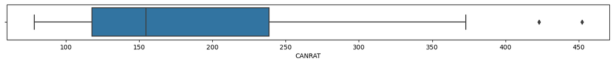

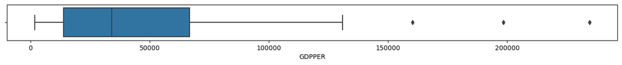

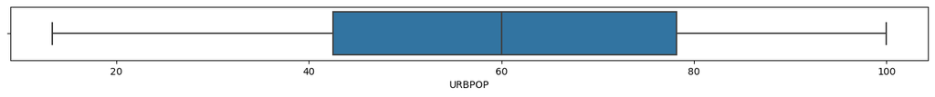

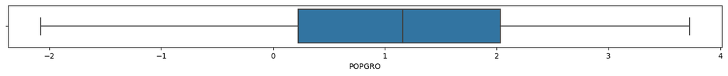

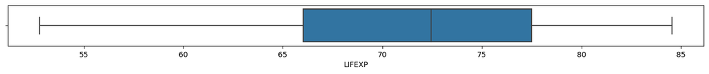

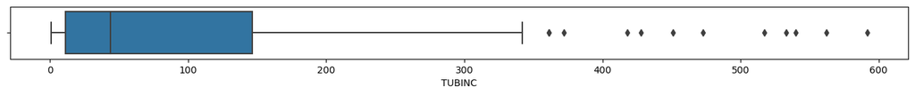

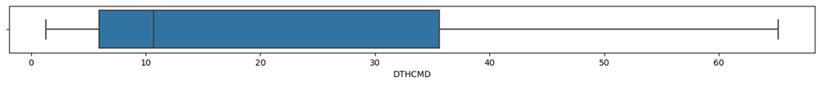

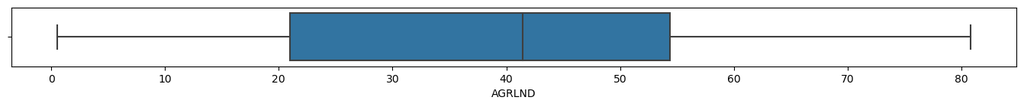

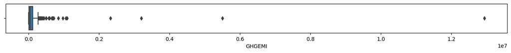

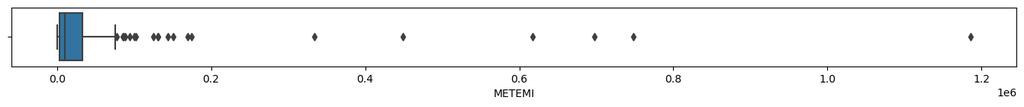

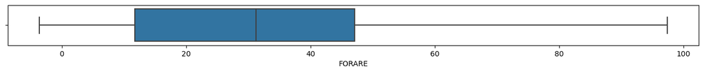

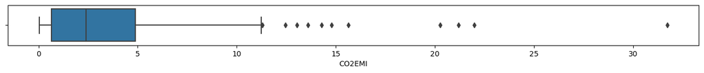

[4 more figures not shown]

```python
##################################
# Formulating the individual boxplots
# for all numeric columns
##################################
for column in cancer_rate_imputed_numeric:
        plt.figure(figsize=(17,1))
        sns.boxplot(data=cancer_rate_imputed_numeric, x=column)
```

### 1.4.4 Collinearity

1. Majority of the numeric variables reported moderate to high correlation which were statistically significant.
2. Among pairwise combinations of numeric variables, high Pearson.Correlation.Coefficient values were noted for:
   - GDPPER and GDPCAP: Pearson.Correlation.Coefficient = +0.921
   - GHGEMI and METEMI: Pearson.Correlation.Coefficient = +0.905
3. Among the highly correlated pairs, variables with the lowest correlation against the target variable were removed.
   - GDPPER: Pearson.Correlation.Coefficient = +0.690
   - METEMI: Pearson.Correlation.Coefficient = +0.062
4. The cleaned dataset is comprised of:
   - **163 rows** (observations)
   - **16 columns** (variables)
     - **1/16 metadata** (object)
       - COUNTRY
     - **1/16 target** (numeric)
       - CANRAT
     - **13/16 predictor** (numeric)
       - URBPOP
       - POPGRO
       - LIFEXP
       - TUBINC
       - DTHCMD
       - AGRLND
       - GHGEMI
       - FORARE
       - CO2EMI
       - PM2EXP
       - POPDEN
       - GDPCAP
       - EPISCO
     - **1/16 predictor** (categorical)
       - HDICAT

```python
##################################
# Formulating a function
# to plot the correlation matrix
# for all pairwise combinations
# of numeric columns
##################################
def plot_correlation_matrix(corr, mask=None):
    f, ax = plt.subplots(figsize=(11, 9))
    sns.heatmap(corr,
                ax=ax,
                mask=mask,
                annot=True,
                vmin=-1,
                vmax=1,
                center=0,
                cmap='coolwarm',
                linewidths=1,
                linecolor='gray',
                cbar_kws={'orientation': 'horizontal'})
```

```python
##################################
# Computing the correlation coefficients
# and correlation p-values
# among pairs of numeric columns
##################################
cancer_rate_imputed_numeric_correlation_pairs = {}
cancer_rate_imputed_numeric_columns = cancer_rate_imputed_numeric.columns.tolist()
for numeric_column_a, numeric_column_b in itertools.combinations(cancer_rate_imputed_numeric_columns, 2):
    cancer_rate_imputed_numeric_correlation_pairs[numeric_column_a + '_' + numeric_column_b] = stats.pearsonr(
        cancer_rate_imputed_numeric.loc[:, numeric_column_a],
        cancer_rate_imputed_numeric.loc[:, numeric_column_b])
```

```python
##################################
# Formulating the pairwise correlation summary
# for all numeric columns
##################################
cancer_rate_imputed_numeric_summary = cancer_rate_imputed_numeric.from_dict(cancer_rate_imputed_numeric_correlation_pairs, orient='index')
cancer_rate_imputed_numeric_summary.columns = ['Pearson.Correlation.Coefficient', 'Correlation.PValue']
display(cancer_rate_imputed_numeric_summary.sort_values(by=['Pearson.Correlation.Coefficient'], ascending=False).head(20))
```

|  | Pearson.Correlation.Coefficient | Correlation.PValue |
| --- | --- | --- |
| GDPPER_GDPCAP | 0.9210 | 0.0000 |
| GHGEMI_METEMI | 0.9051 | 0.0000 |
| POPGRO_DTHCMD | 0.7595 | 0.0000 |
| GDPPER_LIFEXP | 0.7558 | 0.0000 |
| CANRAT_EPISCO | 0.7126 | 0.0000 |
| CANRAT_GDPCAP | 0.6970 | 0.0000 |
| GDPCAP_EPISCO | 0.6967 | 0.0000 |
| CANRAT_LIFEXP | 0.6923 | 0.0000 |
| CANRAT_GDPPER | 0.6868 | 0.0000 |
| LIFEXP_GDPCAP | 0.6838 | 0.0000 |
| GDPPER_EPISCO | 0.6808 | 0.0000 |
| GDPPER_URBPOP | 0.6664 | 0.0000 |
| GDPPER_CO2EMI | 0.6550 | 0.0000 |
| TUBINC_DTHCMD | 0.6436 | 0.0000 |
| URBPOP_LIFEXP | 0.6240 | 0.0000 |
| LIFEXP_EPISCO | 0.6203 | 0.0000 |
| URBPOP_GDPCAP | 0.5592 | 0.0000 |
| CO2EMI_GDPCAP | 0.5502 | 0.0000 |
| URBPOP_CO2EMI | 0.5500 | 0.0000 |
| LIFEXP_CO2EMI | 0.5313 | 0.0000 |

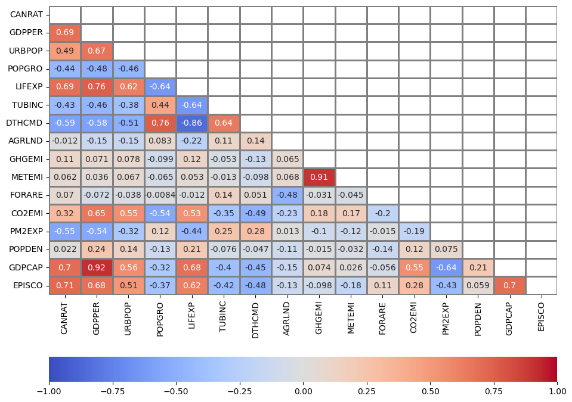

```python
##################################
# Plotting the correlation matrix
# for all pairwise combinations
# of numeric columns
##################################
cancer_rate_imputed_numeric_correlation = cancer_rate_imputed_numeric.corr()
mask = np.triu(cancer_rate_imputed_numeric_correlation)
plot_correlation_matrix(cancer_rate_imputed_numeric_correlation,mask)
plt.show()
```

```python
##################################
# Formulating a function
# to plot the correlation matrix
# for all pairwise combinations
# of numeric columns
# with significant p-values only
##################################
def correlation_significance(df=None):
    p_matrix = np.zeros(shape=(df.shape[1],df.shape[1]))
    for col in df.columns:
        for col2 in df.drop(col,axis=1).columns:
            _ , p = stats.pearsonr(df[col],df[col2])
            p_matrix[df.columns.to_list().index(col),df.columns.to_list().index(col2)] = p
    return p_matrix
```

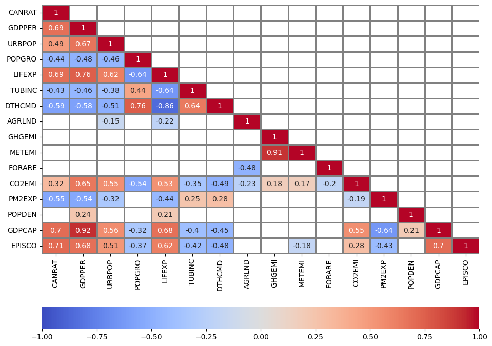

```python
##################################
# Plotting the correlation matrix
# for all pairwise combinations
# of numeric columns
# with significant p-values only
##################################
cancer_rate_imputed_numeric_correlation_p_values = correlation_significance(cancer_rate_imputed_numeric)
mask = np.invert(np.tril(cancer_rate_imputed_numeric_correlation_p_values<0.05))
plot_correlation_matrix(cancer_rate_imputed_numeric_correlation,mask)
```

```python
##################################
# Filtering out one among the
# highly correlated variable pairs with
# lesser Pearson.Correlation.Coefficient
# when compared to the target variable
##################################
cancer_rate_imputed_numeric.drop(['GDPPER','METEMI'], inplace=True, axis=1)
```

```python
##################################
# Performing a general exploration of the filtered dataset
##################################
print('Dataset Dimensions: ')
display(cancer_rate_imputed_numeric.shape)
```

```
Dataset Dimensions:
```

```
(163, 14)
```

### 1.4.5 Shape Transformation

1. A Yeo-Johnson transformation was applied to all numeric variables to improve distributional shape.
2. Most variables achieved symmetrical distributions with minimal outliers after transformation.
3. One variable which remained skewed even after applying shape transformation was removed.
   - PM2EXP
4. The transformed dataset is comprised of:
   - **163 rows** (observations)
   - **15 columns** (variables)
     - **1/15 metadata** (object)
       - COUNTRY
     - **1/15 target** (numeric)
       - CANRAT
     - **12/15 predictor** (numeric)
       - URBPOP
       - POPGRO
       - LIFEXP
       - TUBINC
       - DTHCMD
       - AGRLND
       - GHGEMI
       - FORARE
       - CO2EMI
       - POPDEN
       - GDPCAP
       - EPISCO
     - **1/15 predictor** (categorical)
       - HDICAT

```python
##################################
# Conducting a Yeo-Johnson Transformation
# to address the distributional
# shape of the variables
##################################
yeo_johnson_transformer = PowerTransformer(method='yeo-johnson',
                                          standardize=False)
cancer_rate_imputed_numeric_array = yeo_johnson_transformer.fit_transform(cancer_rate_imputed_numeric)
```

```python
##################################
# Formulating a new dataset object
# for the transformed data
##################################
cancer_rate_transformed_numeric = pd.DataFrame(cancer_rate_imputed_numeric_array,
                                               columns=cancer_rate_imputed_numeric.columns)
```

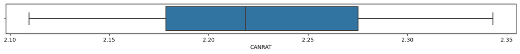

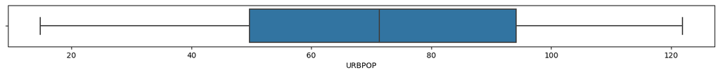

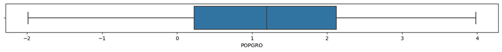

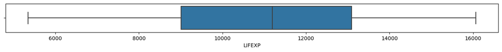

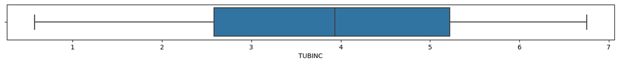

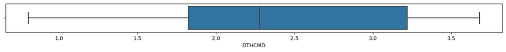

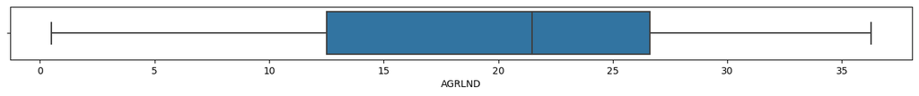

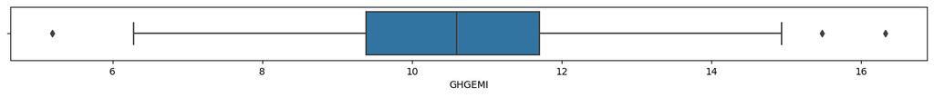

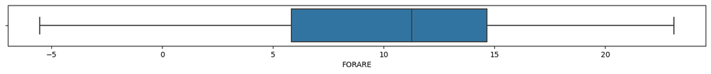

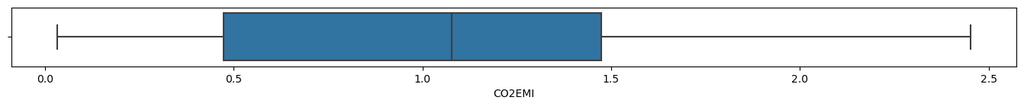

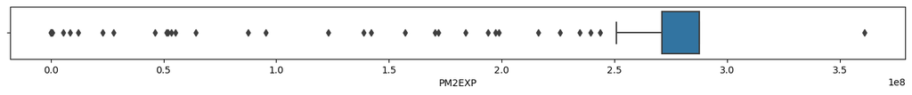

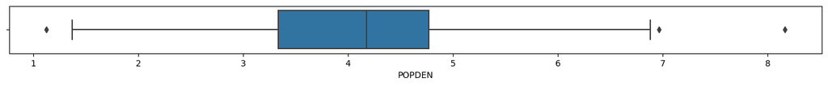

[2 more figures not shown]

```python
##################################
# Formulating the individual boxplots
# for all transformed numeric columns
##################################
for column in cancer_rate_transformed_numeric:
        plt.figure(figsize=(17,1))
        sns.boxplot(data=cancer_rate_transformed_numeric, x=column)
```

```python
##################################
# Filtering out the column
# which remained skewed even
# after applying shape transformation
##################################
cancer_rate_transformed_numeric.drop(['PM2EXP'], inplace=True, axis=1)
```

```python
##################################
# Performing a general exploration of the filtered dataset
##################################
print('Dataset Dimensions: ')
display(cancer_rate_transformed_numeric.shape)
```

```
Dataset Dimensions:
```

```
(163, 13)
```